# Axis tick labels placement in ggplot2

Sangeeta Bhatia

22/12/2017

## Optimal placement of axis tick labels

The parameters vjust and hjust control the horizontal and vertical justification of the text labels. This can be demonstrated in detail by playing around with the example given in the [specs](http://ggplot2.tidyverse.org/articles/ggplot2-specs.html) which is reproduced here.

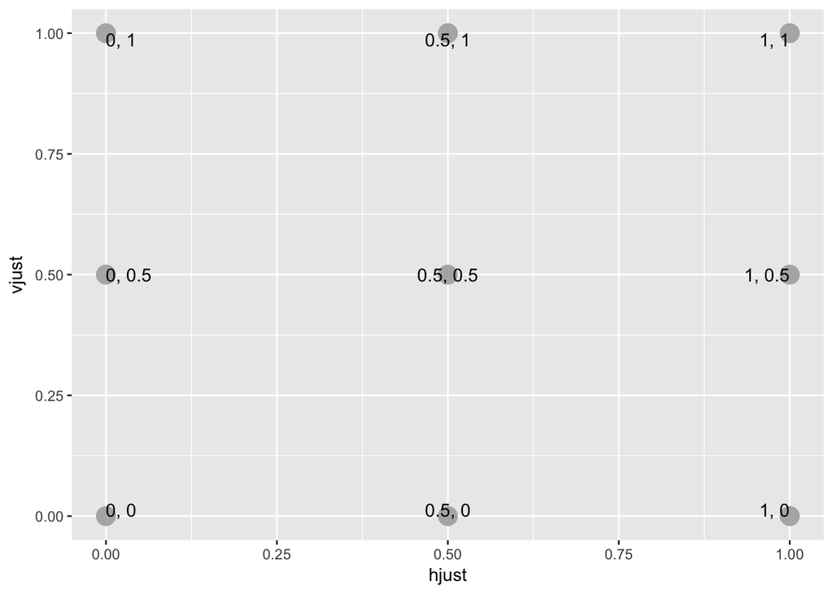

```r
just <- expand.grid(hjust = c(0, 0.5, 1), vjust = c(0, 0.5, 1))
just$label <- paste0(just$hjust, ", ", just$vjust)

ggplot(just, aes(hjust, vjust)) +
  geom_point(colour = "grey70", size = 5) +
  geom_text(aes(label = label, hjust = hjust, vjust = vjust))
```

So the value of hjust moves the label left; the bigger the value, the more left of the point is the label placed.

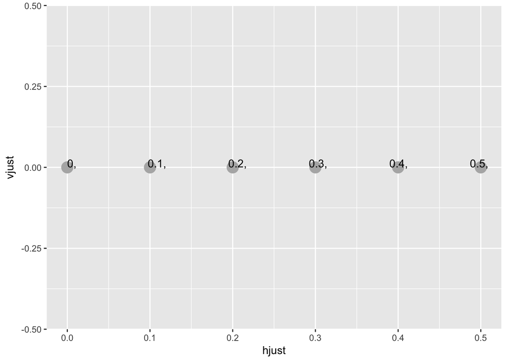

```r
just <- expand.grid(hjust = seq(0, 0.5, by = 0.1), vjust = 0)
just$label <- paste0(just$hjust, ", ")

ggplot(just, aes(hjust, vjust)) +
  geom_point(colour = "grey70", size = 5) +
  geom_text(aes(label = label, hjust = hjust, vjust = vjust))
```

The specs do not recomment the use of values outside the range 0 to 1. However, at least in this particular case, the behavior is as expected.

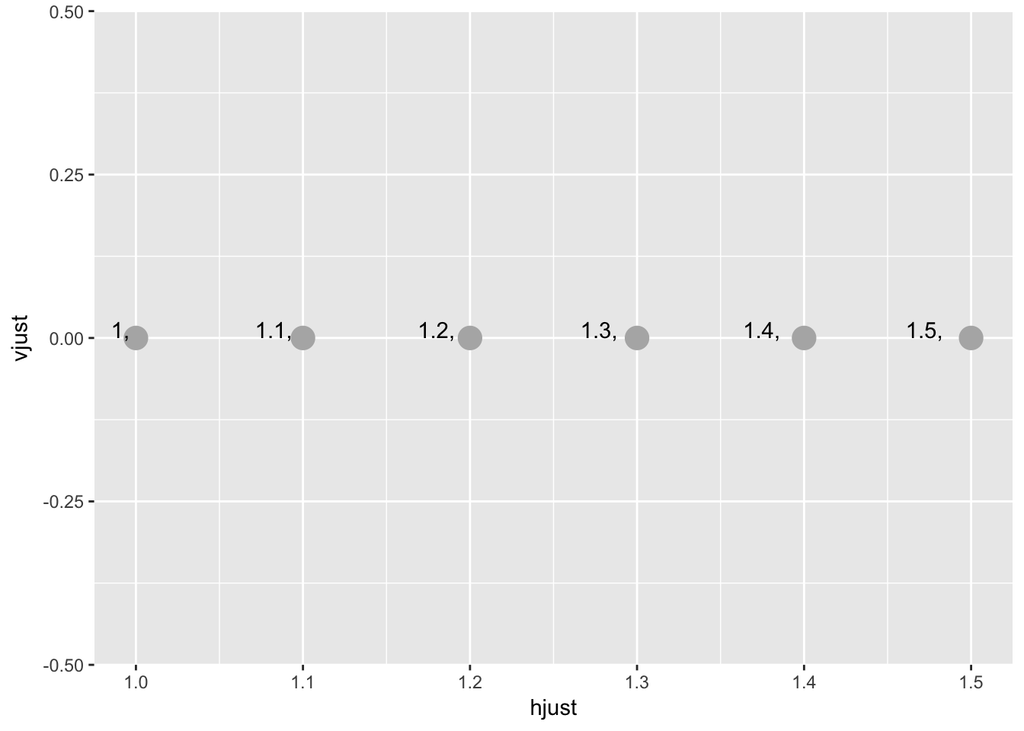

```r
just <- expand.grid(hjust = seq(1.0, 1.5, by = 0.1), vjust = 0)
just$label <- paste0(just$hjust, ", ")

ggplot(just, aes(hjust, vjust)) +
  geom_point(colour = "grey70", size = 5) +
  geom_text(aes(label = label, hjust = hjust, vjust = vjust))
```

What about negative values? Yep, works as expected.

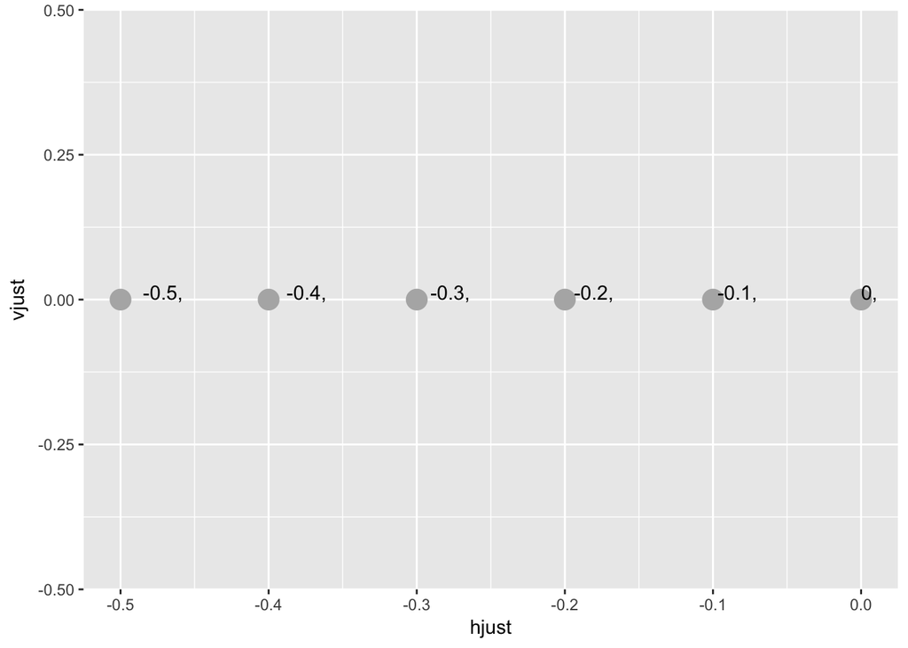

```r
just <- expand.grid(hjust = seq(-0.5, 0, by = 0.1), vjust = 0)
just$label <- paste0(just$hjust, ", ")

ggplot(just, aes(hjust, vjust)) +
  geom_point(colour = "grey70", size = 5) +
  geom_text(aes(label = label, hjust = hjust, vjust = vjust))
```

The same holds true for vjust.

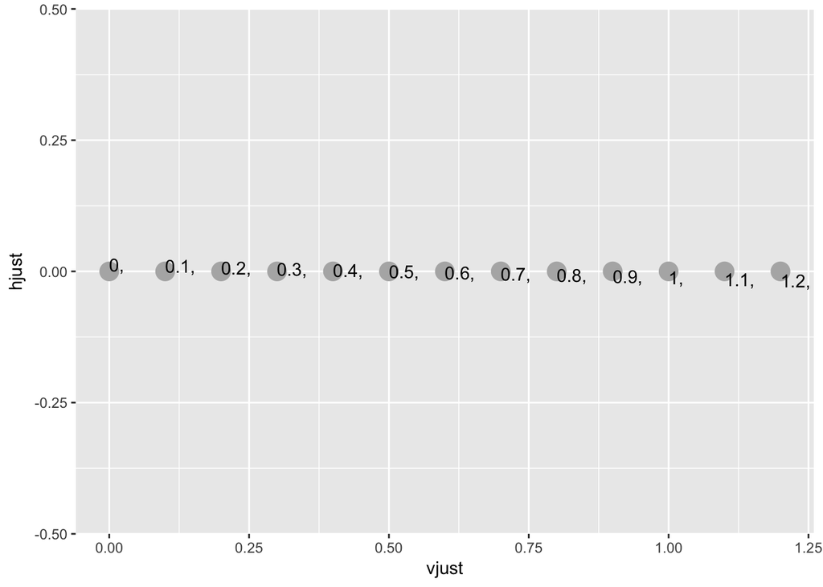

```r
just <- expand.grid(vjust = seq(0, 1.2, by = 0.1), hjust = 0)
just$label <- paste0(just$vjust, ", ")

ggplot(just, aes(vjust, hjust)) +
  geom_point(colour = "grey70", size = 5) +
  geom_text(aes(label = label, hjust = hjust, vjust = vjust))
```

## Axis tick labels

What happens when the axis tick labels are long and have to be rotated? How do the parameters vjust and hjust interact with the angle? In the plot below, the x-axis tick labels begin to overlap each other making the text illegible.

```r
dates <- Sys.Date() + sort(sample(1:100, 100))
```

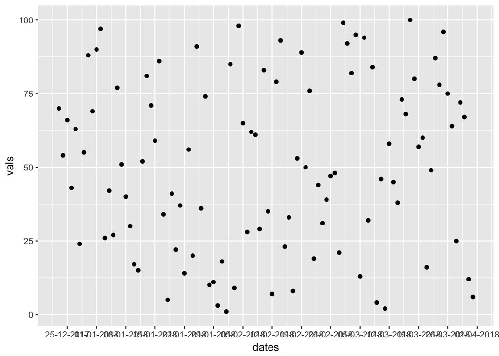

```r
vals  <- sample(1:100, 100)
p <- ggplot(NULL, aes(dates, vals)) +
     geom_point() +
     scale_x_date(date_labels = "%d-%m-%Y", date_breaks = "1 week")

p
```

Placing the labels at an angle makes sense.

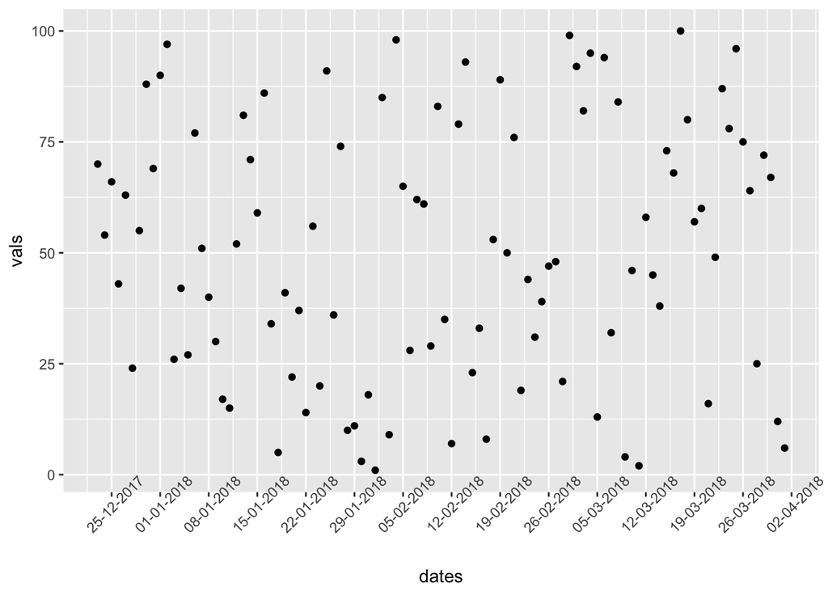

```r
p1 <- p + theme(axis.text.x = element_text(angle = 45))
p1
```

But the labels push into the plot area, which of course makes the plot ugly.

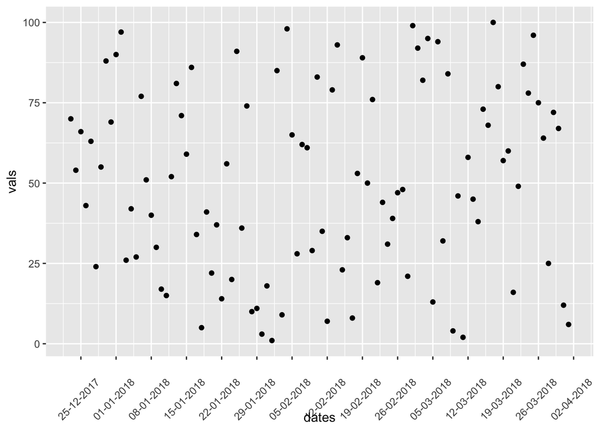

```r
p2 <- p1 + theme(axis.text.x = element_text(vjust = 0.1))
p2
```

But now the labels are placed too far away from the ticks. Perhaps increase vjust?

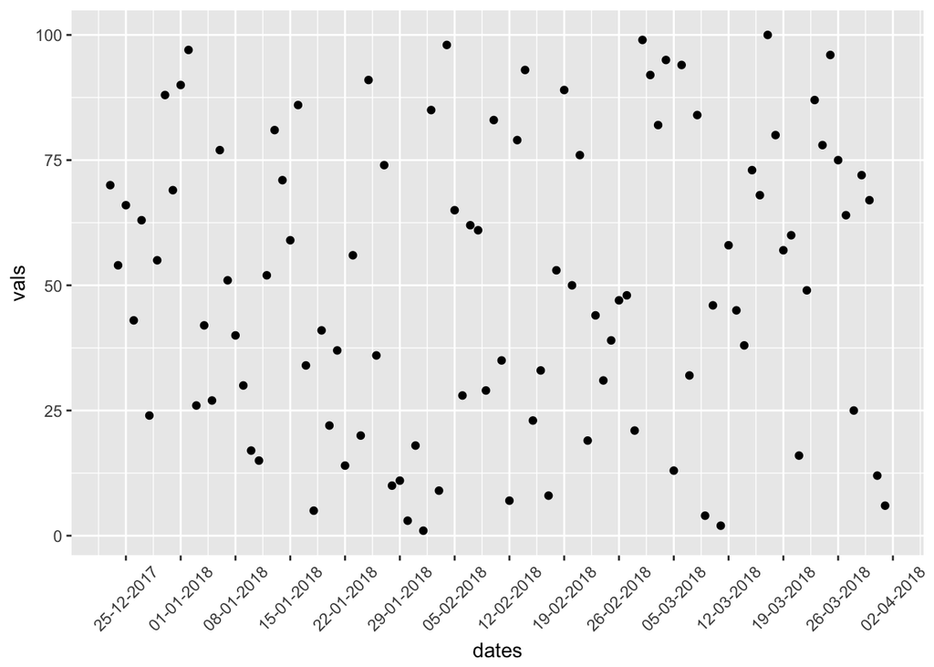

```r
p1 + theme(axis.text.x = element_text(vjust = 0.5))
```

The labels are now midway between ticks, which is a bit annoying. Let is change both params at the same time and see how that influences the label placement.

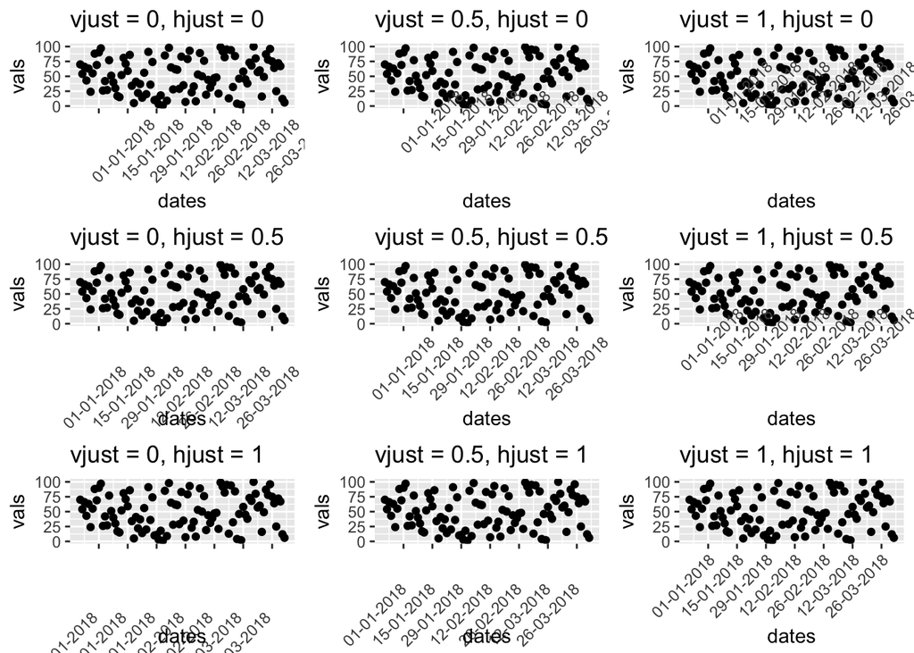

```r
just <- expand.grid(vjust = c(0, 0.5, 1), hjust = c(0, 0.5, 1))
plots <- apply(just, 1, function(row){
  vjust <- row[1]
  hjust <- row[2]
  ggplot(NULL, aes(dates, vals)) +
    geom_point() +
    scale_x_date(date_labels = "%d-%m-%Y", date_breaks = "2 weeks")  +
    theme(axis.text.x = element_text(angle = 45, vjust = vjust, hjust = hjust)) +
    ggtitle(paste0("vjust = ",vjust, ", hjust = ", hjust))

})

cowplot::plot_grid(plotlist = plots)
```

vjust = 1, hjust = 1 brings us closest to the optimal placement!

## TD;DR

1. The bigger the value of hjust, the more left the label is placed;
2. The bigger the value of vjust, the lower the label is placed;
3. It is best not to use values outside the interval [0, 1] for the parameters.